# F(x) XWBTC NAV - yielding WBTC

DC

2024-08-22

*Source:*

*Data from my query: https://dune.com/queries/4009534, source from eth explorer and Chainlink data, transformed via py and r.*

# How XWBTC works

There are several strong assets that can serve as collateral for WBTC. Borrowing stablecoins against BTC can yield higher returns compared to simply lending out BTC. However, borrowing stablecoins carries the risk of liquidation, and looping is less likely due to a reduced LTV (Loan-to-Value) ratio. Currently, there are some wrapped BTC tokens on Ethereum, such as FBTC, tBTC, and swBTC, which enable a Delta Neutral strategy. However, the yields are quite low—for instance, lending swBTC against WBTC on Morpho currently offers only a 1% APR.

But what if we could create a token that captures BTC’s volatility while also generating stable yields? Aladdin DAO offers a protocol called f(x) that allows us to swap BTC for their volatility token, xWBTC. This provides exposure to BTC’s price action without needing to purchase an entire BTC. The remaining funds can then be converted into stablecoins that produce much higher yields. For example, the f(x) BTCUSD stability pool offers an unboosted APR of 13%.

The price of xWBTC is calculated based on the BTC price, the amount of BTC supplied, and the quantity of btcUSD minted.

**xNav = (baseTokenTotalBaseToken * baseTokenPrice - fTokenTotalSupply * fTokenNav) / xTokenTotalSupply**

The table below shows how xWBTC has varied since its launch (cumfwbtc indicates the amount of btcUSD minted). By allocating 40% to stablecoins, the overall position yields 5.2% (13% * 40%), which is significantly higher than the yield from lending WBTC, all while maintaining exposure to BTC price action. This higher yield would make our vaults much more competitive compared to others.

| time | NAV | WBTC | cumfwbtc | BTC_Price | Stable_Proportion |
| --- | --- | --- | --- | --- | --- |
| 2024-08-18 | 0.8598073 | 102.03704 | 2691066 | 59622.64 | 0.4423391 |
| 2024-08-13 | 0.8658833 | 97.40276 | 2690468 | 59792.73 | 0.4619640 |
| 2024-08-12 | 0.8478194 | 96.39818 | 2639754 | 59105.72 | 0.4633031 |
| 2024-08-11 | 0.8756081 | 99.38922 | 2804389 | 60105.56 | 0.4694446 |
| 2024-08-05 | 0.6763326 | 99.06699 | 2897167 | 53020.86 | 0.5515663 |
| 2024-08-03 | 0.9315563 | 103.18412 | 3311620 | 61031.78 | 0.5258617 |
| 2024-08-02 | 1.0162473 | 103.59294 | 3348143 | 63643.78 | 0.5078294 |
| 2024-07-29 | 1.1644341 | 99.45211 | 3148478 | 68338.48 | 0.4632563 |
| 2024-07-28 | 1.1480650 | 99.34085 | 3148473 | 67807.64 | 0.4674050 |
| 2024-07-27 | 1.1596949 | 99.56632 | 3158473 | 68168.48 | 0.4653514 |

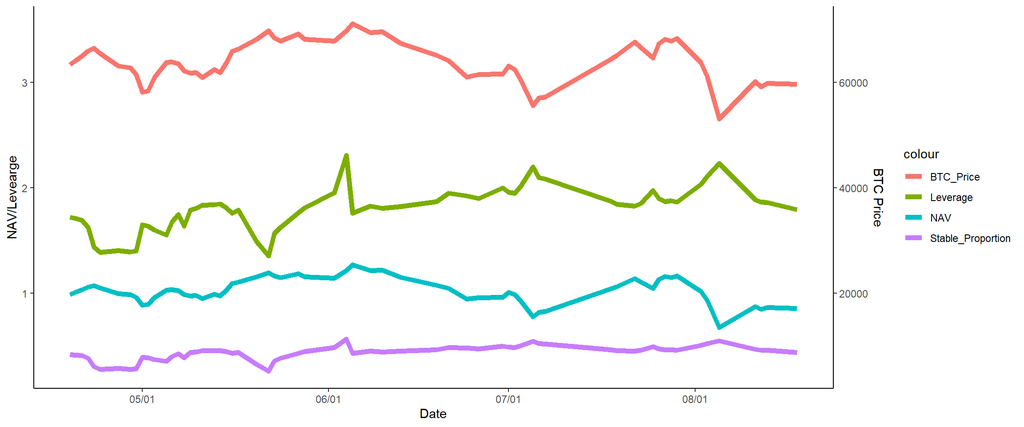

# The Risk

There are a few important considerations to address here. First, creating such a token might not be ecologically valid because it requires the creation of a new token that is composed of two other tokens. Additionally, the position would be exposed to the btcUSD minter. Even if BTC’s price remains stable, an increase in btcUSD minting would reduce the value of XWBTC. As noted in their documentation, btcUSD may lose its stability if there is significant price volatility. https://docs.aladdin.club/f-x-protocol/what-if-bad-things-happen

Moreover, the yield is derived from the f(x) token, FXN, meaning it is subject to FXN’s price fluctuations. If the token’s price drops significantly, it might not remain profitable.

The vault has a cap of 200 BTC and currently holds 100 BTC. Therefore, it seems reasonable to set a cap of 50 BTC for our token. Since we will always purchase btcUSD and XWBTC simultaneously, the value shouldn’t fluctuate too much during the process.

A couple of contract address will be important for this implementation:

0x576b4779727F5998577bb4e25bf726abE742b9F7 - how many btcUSD minted

0xF4030086522a5bEEa4988F8cA5B36dbC97BeE88c - chainlink oracle on BTC price

0x2260FAC5E5542a773Aa44fBCfeDf7C193bc2C599 - how many BTC in the reserve

0x9f23562ec47249761222EF7Ac02b327a8C45Ba7D - how many XWBTC minted